# Transcriptomic Profiling & Spike-in Normalized DEG Analysis Report

Evaluating Global Transcriptional Repression by LUMINIDEPENDENS (LD) in Arabidopsis (GSE292906)

Simon Ho

2026-09-23

```r
# Load core packages for interaction and data visualization
library(data.table)
library(tidyverse)
library(DT)
library(plotly)
library(ggplot2)
```

# Executive Summary & Biological Background

**Dataset Scope — GSE292906**

- **Source Study:** Bergis-Ser C, Wang Q, He X, Nisa M et al. (2025), *Proc Natl Acad Sci U S A* (*LUMINIDEPENDENS orchestrates global transcriptional repression in Arabidopsis*, PMID: 41329727).
- **Biological Organism:** *Arabidopsis thaliana* (7-day-old plantlets).
- **Experimental Groups:**
  - **Control (Col0 / WT):** Wild-type *Arabidopsis thaliana* (Biological triplicates, $n=3$).
  - **Treatment (ld / Mutant):** *luminidependens* loss-of-function mutant (Biological triplicates, $n=3$).
- **Sequencing & Spike-in Control:** Single-end RNA-seq (Illumina NextSeq 500) incorporating exogenous *Drosophila melanogaster* spike-in controls for accurate global transcriptomic scaling.

**Core Research Objective**  
*LUMINIDEPENDENS* ($LD$) was classically recognized as a key autonomous pathway gene regulating flowering time in *Arabidopsis*. However, recent work demonstrates that $LD$ acts as a global transcriptional repressor. Standard median-of-ratios normalization often obscures genome-wide unidirectional expression shifts. By leveraging exogenous *Drosophila* spike-in controls, this analysis quantifies the extent of genome-wide transcriptional activation/derepression triggered by $ld$ loss-of-function.

# Executive Summary Highlights

- **Global Derepression Uncovered:** Exogenous spike-in size factor normalization confirms that loss of $LD$ leads to a massive, asymmetric genome-wide upregulation, verifying the global transcriptional repressor activity of $LD$.
- **PCA & Variance Metrics:** High-throughput PCA reveals that PC1 accounts for the primary biological separation between $Col\text{-}0$ and $ld$, driving distinct sample distance clustering.
- **Reproducible Deliverables:** Complete interactive DEG search tables, annotated volcano plots, high-resolution PC1 driver heatmaps, pathway network maps, and GSEA enrichment profiles.

# 🛠️ Analytical Pipeline Overview (Steps 0–7)

The bioinformatic analysis workflow implemented for GSE292906 follows a robust 8-step pipeline:

- **Step 0: Raw Data Processing & Quantification Pipeline (`0.Upstream_Processing_Pipeline.sh`)**
  - **SRA Retrieval:** Fetches SRA files via `prefetch` and converts them into gzipped FASTQ files using `fasterq-dump` and `pigz`.
  - **Quality Control:** Assesses initial read quality using `FastQC` and aggregates multi-sample reports via `MultiQC`.
  - **Adapter & Quality Trimming:** Cleans raw reads using `fastp` (`--cut_front --cut_tail --cut_mean_quality 20`) to remove low-quality bases and adapters.
  - **Genome Indexing & Alignment:** Aligns trimmed reads to the hybrid reference genome (*A. thaliana* TAIR10 + *D. melanogaster* spike-in) using `HISAT2` and sorts outputs with `samtools`.
  - **Gene Quantification:** Quantifies gene-level read counts across samples using `featureCounts` against the hybrid GTF annotation.
- **Step 1: Data Retrieval & Spike-in Matrix Splitting (`1.GSE292906_matrix_metadata_spike.R`)**  
  Imports featureCounts matrices, maps SRA metadata, and splits endogenous *TAIR10* genes from exogenous *Drosophila* (FBgn) spike-in controls.
- **Step 2: Spike-in Size Factor Calibration & DESeq2 DEG (`2.GSE292906_DEseq2_spike.R`)**  
  Estimates size factors exclusively from *Drosophila* spike-ins and injects them into *TAIR10* DESeq2 analysis to detect true global expression changes without compositional bias.
- **Step 3: VST Variance Transformation & PCA Distance (`3.GSE292906_PCA_Distance_spike.R`)**  
  Applies VST transformation, generates sample distance heatmaps, computes PC loadings, and calculates centroid Euclidean distance between $Col\text{-}0$ and $ld$.
- **Step 4: Annotated Volcano Plot Construction (`4.GSE292906_Volcano_spike.R`)**  
  Annotates TAIR IDs with official gene symbols via `org.At.tair.db`, highlighting top PC1 driver genes and specific targets (e.g., $LD$).
- **Step 5: Truncated Z-Score ComplexHeatmap (`5.GSE292906_Heatmap_spike.R`)**  
  Renders dual-block heatmaps (PC1 Top 30 Positive vs Top 30 Negative loadings) with Z-score truncation $[-2, 2]$ for optimal visual clarity.
- **Step 6: Over-Representation Analysis (`6.GSE292906_ORA_enrichment_spike.R`)**  
  Executes GO (BP/MF) and KEGG enrichment, outputting network `cnetplot` diagrams, `treeplot` clusters, and topology maps via Pathview.
- **Step 7: Gene Set Enrichment Analysis (`7.GSE292906_GSEA_spike.R`)**  
  Ranks the complete transcriptome by $\log_2\text{FC}$ to perform GSEA, generating dotplots, ridgeplots, and classic enrichment profiles.

# 1. Sequencing Quality Control & Read Trimming (Step 0)

Raw FASTQ files were subjected to adapter trimming and quality filtering using **fastp**. Sequence quality metrics, read depth, and trimming efficiency across all biological samples were aggregated using **MultiQC**. The interactive MultiQC report is embedded below:

[interactive chart not shown]

# 2. Spike-in Normalized DEG & Sample Distance (Steps 2–3)

## 🗺️ Sample Distance Heatmap

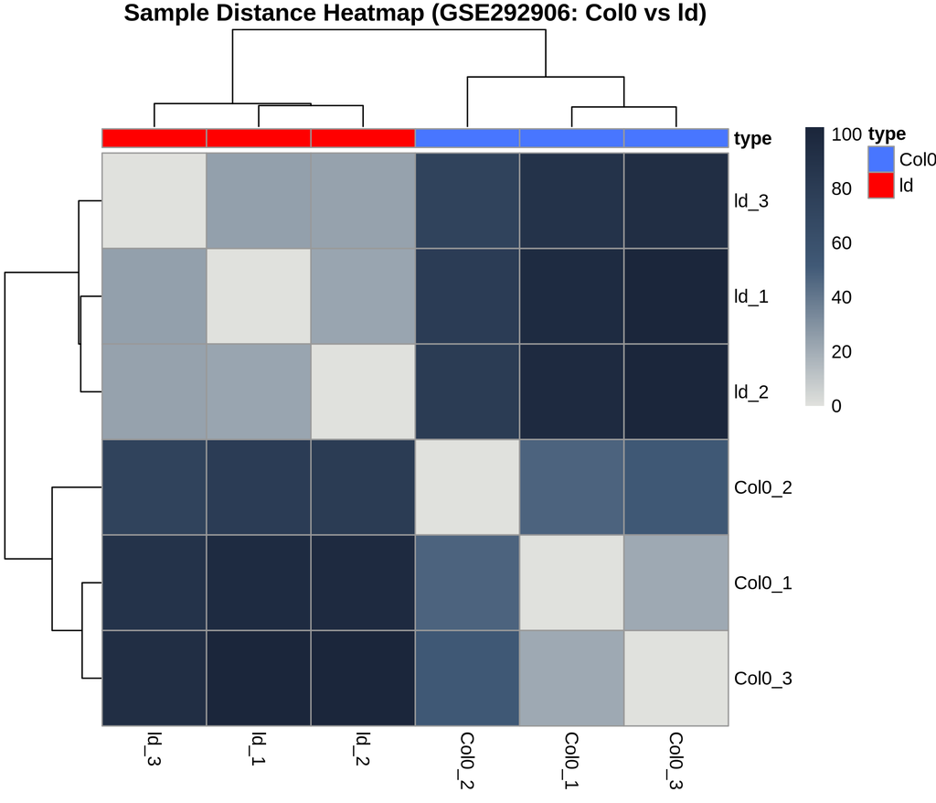

**Sample Distance Interpretation**

- The hierarchical clustering clearly separates the Col0 and ld samples into two distinct biological groups with high within-group consistency.

## 📊 Interactive DEG Table (Searchable)

```r
if (file.exists("./GSE292906_DEG_ld_vs_Col0_annotated.tsv")) {
  deg_df <- fread("./GSE292906_DEG_ld_vs_Col0_annotated.tsv")

  datatable(
    deg_df,
    filter = 'top',
    extensions = 'Buttons',
    caption = 'Table 1: DESeq2 Differential Expression Results (Spike-in Size Factor Normalized)',
    options = list(
      pageLength = 10,
      dom = 'Bfrtip',
      buttons = c('copy', 'csv', 'excel')
    )
  ) %>%
    formatSignif(columns = c("pvalue", "padj"), digits = 3) %>%
    formatRound(columns = c("log2FoldChange", "stat", "lfcSE"), digits = 2)
} else {
  cat("DEG results table not found in ./ directory.")
}
```

|  | tair_id | baseMean | log2FoldChange | lfcSE | stat | pvalue | padj | symbol_annot | symbol | change | change_labeled |
| --- | --- | --- | --- | --- | --- | --- | --- | --- | --- | --- | --- |
| 1 | AT1G78930 | 95.5570692645406 | 0.786775965447606 | 0.226933723141717 | 3.46698566680755 | 0.000526329954919805 | 0.000875080165348076 | mTERF16 | mTERF16 | Up-regulated | Up-regulated (16804) |
| 2 | AT1G71695 | 5701.30246024797 | 0.675891595174513 | 0.0869172696696619 | 7.77626354052893 | 7.4698010183861e-15 | 1.29755322185367e-13 |  | AT1G71695 | Up-regulated | Up-regulated (16804) |
| 3 | AT1G56250 | 13.1674494595843 | 0.107392643132675 | 0.479338176863385 | 0.224043584083816 | 0.822723389915905 | 0.833879789442628 | AtPP2-B14 | AtPP2-B14 | NotSig | NotSig |
| 4 | AT1G69810 | 467.729339058164 | 0.976180692911519 | 0.166346401002527 | 5.86836076421448 | 4.40124777969567e-09 | 2.11888938712194e-08 | ATWRKY36 | ATWRKY36 | Up-regulated | Up-regulated (16804) |
| 5 | AT1G72450 | 335.452149744358 | 0.630665055835975 | 0.12987436937854 | 4.85596241085721 | 1.19803428376211e-06 | 3.47236656261646e-06 | JAZ6 | JAZ6 | Up-regulated | Up-regulated (16804) |
| 6 | AT1G76280 | 355.532287813156 | 0.537622556365862 | 0.131373278834178 | 4.09232806805757 | 4.27063870508821e-05 | 8.84957634891535e-05 |  | AT1G76280 | Up-regulated | Up-regulated (16804) |
| 7 | AT1G15210 | 1255.58883288725 | 0.923273695074872 | 0.101408495744644 | 9.10450044934855 | 8.66643414346369e-20 | 4.41513858851086e-18 | ABCG35 | ABCG35 | Up-regulated | Up-regulated (16804) |
| 8 | AT1G15250 | 625.786895865667 | 0.735401520140037 | 0.176844262822325 | 4.15846976545059 | 3.20386628175092e-05 | 6.81787005925382e-05 | RPL37A | RPL37A | Up-regulated | Up-regulated (16804) |
| 9 | AT1G79700 | 1400.31120755278 | 0.374004971465099 | 0.128191164124257 | 2.91755655719433 | 0.00352785663943229 | 0.0050436651989929 | WRI4 | WRI4 | Up-regulated | Up-regulated (16804) |
| 10 | AT1G73360 | 71.6186512603286 | 0.283012994042155 | 0.212277910393561 | 1.33321923848531 | 0.182459867707587 | 0.201675224673547 | AtEDT1 | AtEDT1 | NotSig | NotSig |

[output cut: 20470 more lines]

# 3. Global Trajectory & PCA Driver Loadings (Step 3)

## 📊 PCA Projection (Biplot)

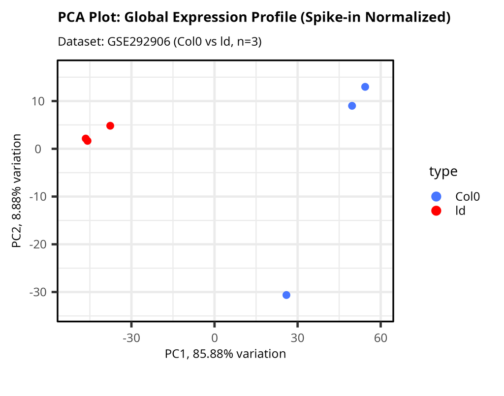

## 📈 PC1 Loadings Barplot

[figure not shown]

## 📋 Top PC1 Loadings Table

```r
if (file.exists("./GSE292906_PC1_loadings.tsv")) {
  loadings_df <- fread("./GSE292906_PC1_loadings.tsv")

  datatable(
    head(loadings_df, 100),
    filter = 'top',
    caption = 'Table 2: Top 100 Genes Driving PC1 Separation (Col0 vs ld)',
    options = list(pageLength = 8, dom = 'Bfrtip')
  ) %>% formatRound(columns = c("loading"), digits = 4)
} else {
  cat("PC1 loadings table not found in ./.")
}
```

|  | symbol | loading |
| --- | --- | --- |
| 1 | AT3G55920 | -0.041023148861676 |
| 2 | AT5G10140 | -0.0392687795166117 |
| 3 | AT5G14110 | -0.0352646306248939 |
| 4 | AT1G77960 | -0.0300310446353935 |
| 5 | AT3G55910 | -0.0294618304255633 |
| 6 | AT1G49570 | -0.0275650206486662 |
| 7 | AT1G14250 | -0.0275457076424939 |
| 8 | AT1G05397 | -0.0270479146285743 |
| 9 | AT2G03020 | -0.0266050349491533 |
| 10 | AT3G06355 | -0.0265891949970216 |

[output cut: 90 more lines]

## 📏 Centroid Distance Metric

```r
if (file.exists("./GSE292906_PC1_PC2_distance_summary.tsv")) {
  dist_summary <- fread("./GSE292906_PC1_PC2_distance_summary.tsv")

  datatable(
    dist_summary,
    options = list(dom = 't'),
    rownames = FALSE,
    caption = 'Table 3: Quantified Centroid Distance across PC1 & PC2'
  )
} else {
  cat("Centroid distance summary not found in ./.")
}
```

| Metric | Value |
| --- | --- |
| Dist_Col0_to_ld_PC1_PC2 | 86.86 |

# 4. Transcriptomic Profiling & Heatmap (Steps 4–5)

## 📌 Publication Volcano Plot

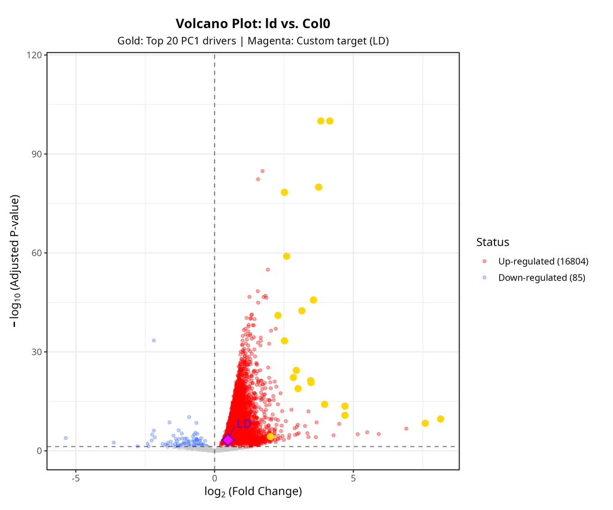

## 🧬 ComplexHeatmap Profiling

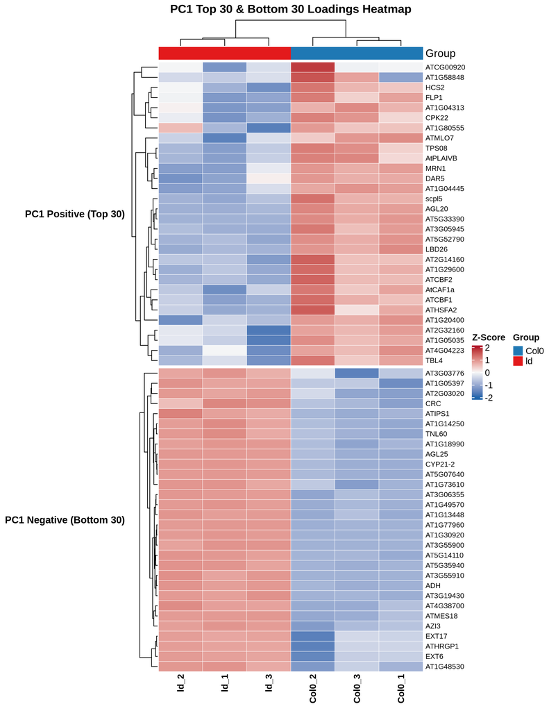

**Heatmap Pattern Interpretation**

- The heatmap illustrates a clear transcriptomic shift where PC1 positive-loading genes associated with normal development are downregulated in the ld mutant.
- whereas PC1 negative-loading genes involved in defense, stress response, and cell wall modification are highly activated.

# 5. Over-Representation & Pathway Topology (Step 6)

## 🕸️ GO BP Cnetplot

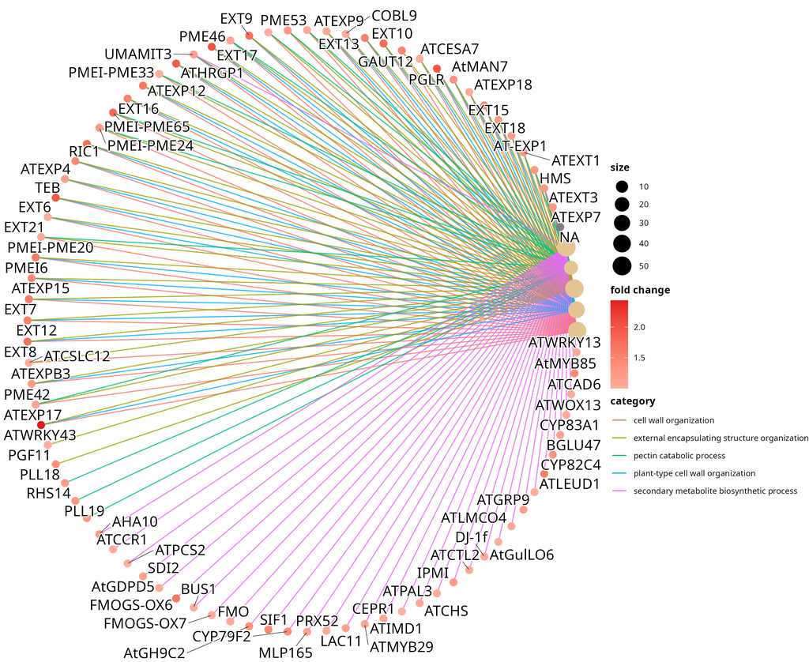

## ⭕ GO BP Cluster Treeplot

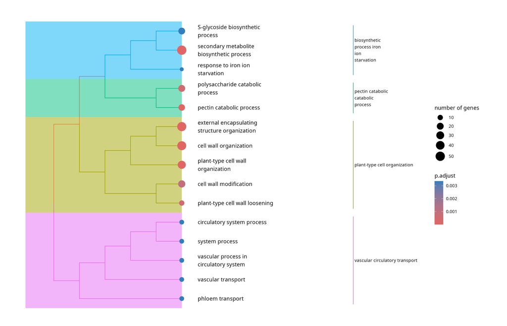

**GO BP Cluster Interpretation**

- GO enrichment analysis reveals that the up-regulated genes are predominantly clustered in cell wall organization and modification, secondary metabolite biosynthesis, and vascular transport processes.
- Biologically, this suggests that the loss of $LD$ triggers a coordinated stress response and cell wall remodeling, likely compensating for developmental or structural disruptions caused by the mutation.

## 🗺️ KEGG Pathview (Phenylpropanoid Biosynthesis)

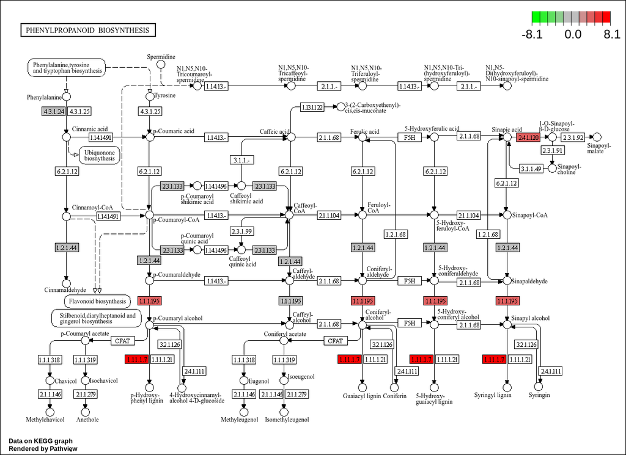

**Biological Pathway Summary**

# 6. Gene Set Enrichment Analysis (GSEA) (Step 7)

## 🔵 GO BP Dotplot Overview

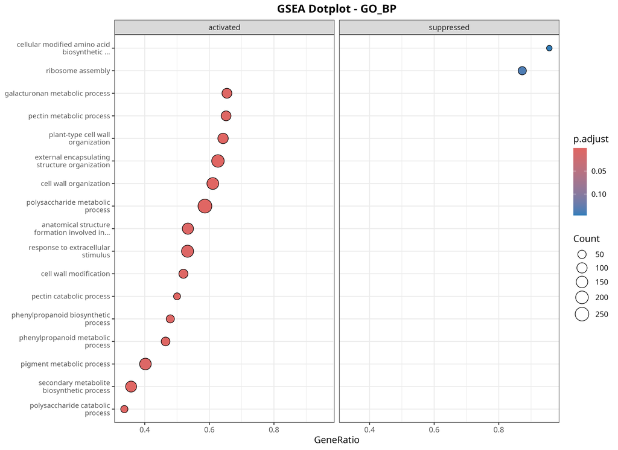

## ⛰️ GO BP Ridgeplot

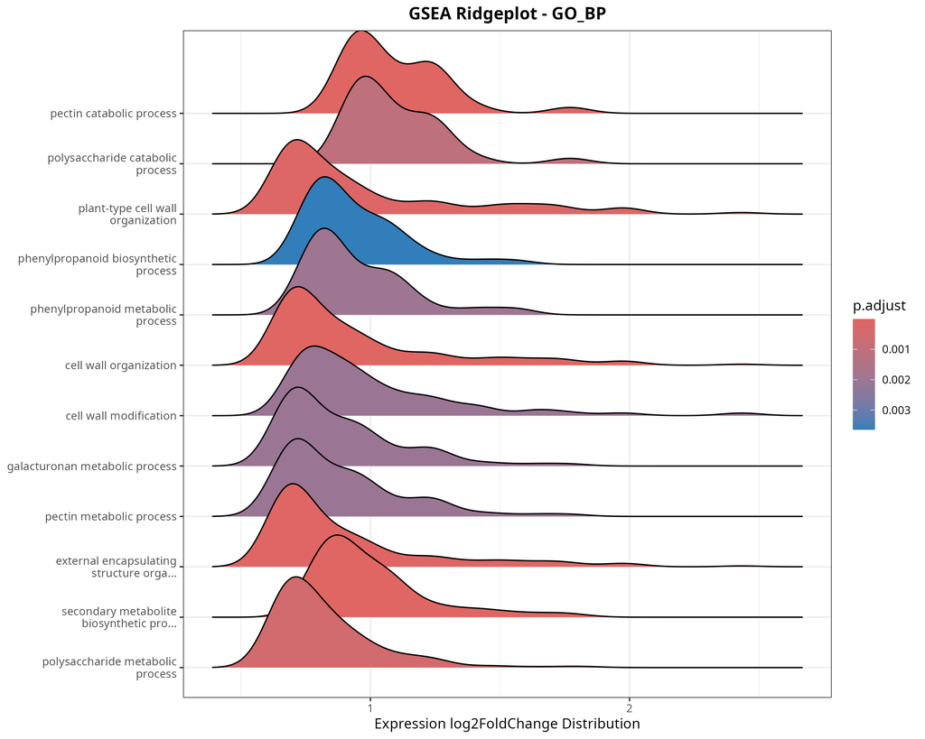

**GO BP Ridgeplot Interpretation**

- The GSEA ridgeplot demonstrates a widespread positive shift in expression for pathways related to cell wall modification, pectin catabolism, and secondary metabolism.
- Biologically, this uniform activation across entire gene sets indicates that the loss of $LD$ induces systematic structural reorganization of the cell wall and metabolic reprogramming, rather than isolated gene-level fluctuations.

## 📈 Top KEGG Enrichment Profile (ath00940)

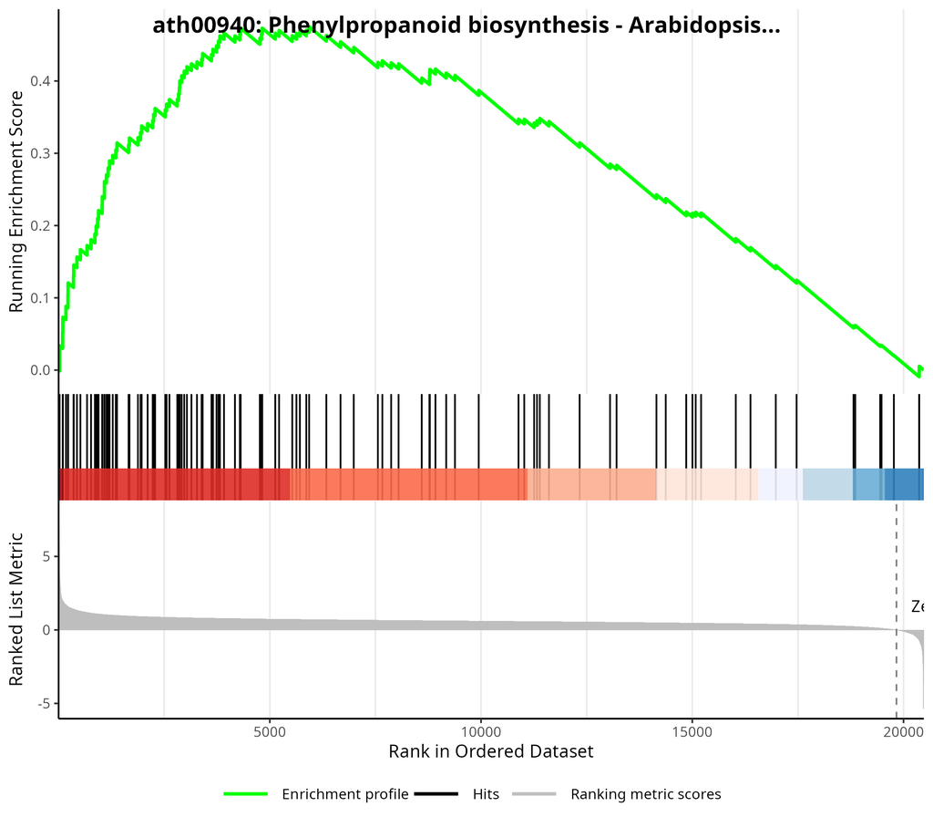

**GSEA Insights**

- GSEA analysis demonstrates strong positive enrichment for the phenylpropanoid biosynthesis pathway (ath00940), reaching a high peak Running Enrichment Score (RES) of approximately 0.48 at the top-ranked gene positions (around Rank 5,000 out of ~20,000 total genes).
- Biologically, this dramatic upregulation of pathway genes indicates a robust metabolic shift toward lignin biosynthesis and cell wall reinforcement in the $ld$ mutant.